# Análisis de sentimiento en foros de inversión cripto.

Tarea 3: Análisis de Datos No Estructurados

Autor/a

Carles Villar

Fecha de publicación

3 diciembre 2025

# 1 Análisis de sentimiento en foros de inversión cripto.

El mercado cripto no es como la bolsa tradicional, no descansa, es un mercado en constante movimiento las 24 horas, y en el que los sentimientos pueden cambiar de alegria a miedo o arrrepentimiento por una caída en cuestión de minutos. Pero, ¿como medimos ese ruido?

Este trabajo se propone capturar esta carga emocional y descubrir las emociones que se esconden detrás de centenares de comentarios sobre el mercado cripto. Mediente el análisis de discusiones en el foro de Reddit r/CryptoCurrency, en el que miles de inversores dan su opinión y sus sentimientos hacia el mercado.

Dado que nos enfrentamos a unos datos desestructurados, lenguaje informal e ironías, el objetivo no es solo describir lo que dicen o sienten, sino evaluar que técnicas de análisis de sentimiento es más eficaz para medir el pulso emocional de este mercado

## 1.1 SCRAPEO Y EXTRACCIÓN DE DATOS

Para este análisis, la extracción de datos ha sido relativamente sencilla. Utilizando la librería de RedditExtractoR, nos hemos conectado directamente a la API de Reddit y hemos conseguido extraer los comentarios del [Daily Discussion Thread](https://www.reddit.com/r/CryptoCurrency/comments/1onttbm/daily_crypto_discussion_november_4_2025_gmt0/) del 4 de noviembre del 2025, un hilo donde se concentra la actividad frenética del día a día.

Al conectar con la API, descargamos la estructura del hilo y aislamos los comentarios, que es realmente lo que nos interesa para ver el verdadero valor sentimental.

Aunque el hilo contiene mas de 2000 comentarios, esta extracción recopila únicamente los niveles superiores y las respuestas principales. Esta limitación de la API nos proporciona una ventaja ya que nos asegura un corpus manejable con contenido de calidad y evita el posible ruido de comentarios irrelevantes.

**Código**

```r
library(stringr)
library(RedditExtractoR)
library(tidyverse)
library(tidytext)
library(stringi)
library(sentimentr)
library(textdata)
library(dplyr)
library(ggplot2)
```

**Código**

```r
# DEFINIR URL DE REDDIT

url <- "https://www.reddit.com/r/CryptoCurrency/comments/1onttbm/daily_crypto_discussion_november_4_2025_gmt0/"

# SCRAPEAR CONTENIDO Y SACAR
contenido <- get_thread_content(url)

#GUARDAR COMENTARIOS
df<- contenido$comments
```

## 1.2 PREPROCESAMIENTO

Para que el análisis sea riguroso, nuestra materia prima de Reddit, al ser una fuente informal donde cada usuario vierte su opinión, presentaba un alto grado de ruido y desestructuración. Antes de aplicar cualquier técnica de polaridad , hemos procedido con una etapa de limpieza y normalización para eliminar elementos irrelevantes como urls o emojis y asegurar la consistencia del corpus.

El primer paso fue comprobar la existencia de emojis. En los foros de criptomonedas es muy habitual usar símbolos como el cohete “🚀” para señalar una subida explosiva o el gráfico bajista “📉” para alertar de una caída de valor.

Sin embargo, tras realizar el recuento, comprobamos que en este hilo no aparecían. Al confirmar que el texto es puramente alfanumérico, pudimos proceder con una limpieza estándar sin miedo a perder información emocional clave.

**Código**

```r
lista_emojis <- str_extract_all(df$comment, "[\\p{Extended_Pictographic}]")
todos_los_emojis <- unlist(lista_emojis)
todos_los_emojis
```

```
character(0)
```

Una vez descartada la presencia de emojis, el siguiente paso es asegurar que no hay sesgo de repetición, ya que en un foro de Reddit es normal encontrar algunos bots o usuarios que repitan el mismo comentario varias veces, lo que es conocido como spam.

En caso de no realizar este proceso, corremos el riesgo de que el análisis de sentimiento se distorsione, por ejemplo si un usuario comenta muchas veces un comentario positivo, pude sesgar nuestro análisis hacia una opinión más optimista sobre la situación del mercado. De este modo evitamos este tipo de situaciones y nos aseguramos de medir la diversidad de opiniones.

**Código**

```r
df <- df %>%
  dplyr::distinct(comment, .keep_all = TRUE)

set.seed(123)
preview <- df |>
  transmute(
    id = row_number(),
    preview = sapply(strsplit(comment, "\\s+"),
                     function(x) paste(head(x, 12), collapse = " "))
  ) |>
  slice_sample(n = 5)
print(preview)
```

```
   id                                                     preview
1 415 look this isn't hopium and don't let it influence you but I
2 179   Dog and frog coins not getting you a dream car, who would
3  14                                    It's one point away, 20%
4 195              Yall said this at 110k, 105k, 100k, etc...lmao
5 426                                       Post your shorts then
```

Una vez eliminados los duplicados y los emojis nos queda el texto en bruto, que puede venir con problemas de formato. Para solucionarlo aplicamos la función de limpieza vista en clase para estandarizar los comentarios.

Este proceso normaliza la codificación y realiza una transliteración a ASCII, lo que convierte los caracteres especiales o tildes en su equivalente simple, de esta manera evitamos que los algoritmos se confundan entre símbolos extraños. Además, eliminamos caracteres invisibles de control y los espacios en blanco sobrantes. Básicamente, preparamos el texto para que cuando usemos los modelos de análisis solo procesen las palabras sin ningún tipo de ruido que pueda interferir en los resultados.

**Código**

```r
clean_one <- function(s) {
  if (is.na(s)) return(NA_character_)
  s <- iconv(s, from = "", to = "UTF-8", sub = "byte")                      # normaliza codificación
  s <- stringi::stri_trans_general(s, "Any-ASCII")                           # translitera a ASCII
  s <- stringi::stri_replace_all_regex(s, "[\\p{Cf}\\uFE0F\\uFE0E]", "")     # invisibles
  s <- stringi::stri_trim_both(stringi::stri_replace_all_regex(s, "\\s+", " "))# espacios
  s
}
df$comment <- vapply(as.character(df$comment), clean_one, FUN.VALUE = character(1), USE.NAMES = FALSE)
```

## 1.3 ANÁLISIS DE SENTIMIENTO

Tal como hemos estudiado en el temario existen varios métodos para medir el sentimiento en datos no estructurados, no existe un método infalible pero sí que existen algunos que funcionan mejor que otros en según que ámbitos, y esa es nuestra función, la de determinar que método es el que mejor funcionará para lo que queremos analizar.

Para este análisis he decidido comparar dos enfoques distintos, para ver cuál captura mejor la realidad, el enfoque de dominio con Lougrhran y el enfoque contextual con sentimentr.

### 1.3.1 SENTIMENTR

Una vez tenemos los datos limpios, nos ponemos manos a la obra con el primer método. El principal motivo para escoger sentimentr, es su capacidad de leer contexto. A diferencia de diccionarios estáticos, que simplemente suman puntos, este método usa recursos del paquete lexicon para entender como hablamos realmente, detectando ironías y comentarios informales.

Su capacidad de leer contexto se basa, por un lado,en utilizar el hash_sentiment_jockers_rinker para establecer la carga positiva y negativa de cada término. Pero la verdadera ventaja de esta herramienta, radica en el seguno componente, el hash_valence_shifters. Este componente detecta modificadores conceptuales, como intensificadores que alteran el sentido real de la frase. De esta manera el modelo tiene la capacidad de invertir el signo o escalar la intensidad emocional de la oración en su contexto, permitiendo captar la ironía de los comentarios mejor que un diccionario estático.

Un ejemplo de como funciona sería un comentario como “Esta caída no es realmente mala”, un diccionario estático vería las palabras caída y mala y puntuaria esta frase como muy negativa. En cambio con sentimentr, detectamos la palabra mala y lo puntuamos negativo, detecta la palabra realmente y lo amplifica es decir si lo puntuaba con un -1 ahora como un -5, pero luego dentro del contexto sigue escaneando y ve el no, lo cual identifica como un negador, por lo que le suma +5 puntos positivos y dejaría este comentario en neutro.

En cuanto al procesamiento para el análisis de sentimiento de los comentarios ha sido el visto en clase.

**Código**

```r
#CARGA DE LÉXICOS
polaridad <- lexicon::hash_sentiment_jockers_rinker
polaridad
```

```
Clave <x>
                 x     y
            <char> <num>
    1:      a plus  1.00
    2:     abandon -0.75
    3:   abandoned -0.50
    4:   abandoner -0.25
    5: abandonment -0.25
   ---
11706:      zenith  0.40
11707:        zest  0.50
11708:       zippy  1.00
11709:      zombie -0.25
11710:     zombies -0.25
```

**Código**

```r
modificadores <- lexicon::hash_valence_shifters
modificadores
```

```
Clave <x>
              x      y
         <char> <char>
  1: absolutely      2
  2:      acute      2
  3:    acutely      2
  4:      ain't      1
  5:       aint      1
 ---
136:    whereas      4
137:      won't      1
138:       wont      1
139:   wouldn't      1
140:    wouldnt      1
```

**Código**

```r
#CALCULO DE LA POLARIDAD DE CADA FRASE

# 1) Lista de frases
sents_list <- sentimentr::get_sentences(df$comment) # Divide texto en oraciones

# 2) Data frame con el texto de cada frase (para poder mostrar 'sentence')
sents_df <- data.frame(
  element_id  = rep(seq_along(sents_list), lengths(sents_list)),
  sentence_id = sequence(lengths(sents_list)),
  sentence    = unlist(sents_list, use.names = FALSE),
  stringsAsFactors = FALSE
)

# Calcula sentimiento por frase
sent_frase <- sentimentr::sentiment(sents_list)
```

Como sentimentr necesita trabajar a nivel de oración para entender el contexto real, lo primero que hacemos es cargar los dos léxicos clave: el que define la polaridad y el que detecta los modificadores. Con las herramientas listas, dividimos los comentarios en frases independientes respetando la puntuación original, preparando así el terreno para que el algoritmo pueda ‘leer’ cada idea por separado.

Una vez tenemos las oraciones listas, creamos una tabla de referencia para no perder el rastro de qué frase pertenece a qué comentario. Con todo organizado, ejecutamos por fin el cálculo de polaridad, obteniendo una puntuación numérica para cada fragmento.

**Código**

```r
# Une el score a la frase y selecciona columnas clave
auditoria_frase <- sent_frase %>%
  dplyr::left_join(sents_df, by = c("element_id","sentence_id")) %>%
  dplyr::select(element_id, sentence_id, sentence, word_count, sentiment)

# Muestra primeras 5 filas
auditoria_frase %>%
  select(element_id, sentence_id, sentence, word_count, sentiment) %>%
  slice_head(n = 5)
```

```
   element_id sentence_id
        <int>       <int>
1:          1           1
2:          1           2
3:          1           3
4:          1           4
5:          2           1
                                                                                                                            sentence
                                                                                                                              <char>
1:                                                                              We've launched a r/CryptoCurrency and Moons Discord!
2:              Join to chat about crypto and moons, sign up for news, governance, and other alerts, and watch burns as they happen!
3:                                           https://discord.gg/ZuU9Gqeqmy *I am a bot, and this action was performed automatically.
4: Please [contact the moderators of this subreddit](/message/compose/?to=/r/CryptoCurrency) if you have any questions or concerns.*
5:                                                                                The beatings shall continue until morale improves.
   word_count   sentiment
        <int>       <num>
1:          8 -0.17677670
2:         21 -0.03273268
3:         15 -0.12909944
4:         19  0.24088652
5:          7  0.34016803
```

Una vez se ha calculado la polaridad de cada oración, el siguiente paso es la auditoría. Este bloque es fundamental porque relaciona la puntuación numérica que el modelo ha generado sent_frase con el texto real de la oración. Al crear la tabla auditoria_frase, podemos revisar y validar las primeras filas para asegurarnos de que el algoritmo está entendiendo correctamente las negaciones y los amplificadores dentro de su contexto.

**Código**

```r
# --- CÁLCULO Y AGRUPACIÓN FINAL ---
#agrega las puntuaciones a nivel de comentario
resultado_por_comentario <- sent_frase %>%
  group_by(element_id) %>%
  summarise(
    n_sentences = n(),
    sent_mean   = mean(sentiment),   # media por frase
    sent_sum    = sum(sentiment),    # suma por reseña
    .groups     = "drop"
  ) %>%
  mutate(
    label = case_when(
      sent_mean >  0 ~ "Positive",
      sent_mean <  0 ~ "Negative",
      TRUE           ~ "Neutral"
    ),
    text = df$comment[element_id]
  ) %>%
  relocate(element_id, text, n_sentences, sent_mean, sent_sum, label)
```

Una vez tenemos todas las oraciones analizadas, agrupamos los datos por el comentario original element_id para calcular la nota media sent_mean, que representa la polaridad general del inversor en ese mensaje. Esta puntuación final es la que nos da el veredicto, clasificando la opinión como ‘Positiva’, ‘Negativa’ o ‘Neutra’, lista para ser interpretada en los resultados.

#### 1.3.1.1 Análisis resultados

Una vez realizado el análisis pasamos a ver los resultados que nos propone este método. Lo primero que vamos a hacer es analizar los 10 comentarios más positivos y los 10 comentarios más negativos por la media. Esto nos ayuda a ver si realmente este modelo ha sido capaz de clasificar correctamente los comentarios positivos y los negativos.

**Código**

```r
# Top 10 más negativas (por media)
resultado_por_comentario %>% arrange(sent_mean) %>% slice_head(n = 10)
```

```
# A tibble: 10 × 6
   element_id text                          n_sentences sent_mean sent_sum label
        <int> <chr>                               <int>     <dbl>    <dbl> <chr>
 1         24 "Battered and deep fried."              1    -1.35    -1.35  Nega…
 2        334 "Hate to use the N word arou…           1    -0.815   -0.815 Nega…
 3        206 "before the massive shake xD"           1    -0.805   -0.805 Nega…
 4        112 "Bull trap, going lower"                1    -0.75    -0.75  Nega…
 5        110 "Not sure about that but con…           2    -0.744   -1.49  Nega…
 6        275 "This is sickening what the …           1    -0.714   -0.714 Nega…
 7        240 "DOW JONES : 47.085,24 \u001…           1    -0.620   -0.620 Nega…
 8        160 "This a real bounce or a dea…           1    -0.6     -0.6   Nega…
 9        182 "Fuck this market."                     1    -0.577   -0.577 Nega…
10        207 "copium\\_tank.jpeg"                    1    -0.577   -0.577 Nega…
```

Este análisis manual de los 10 comentarios más negativos nos permitirá cuantificar la calidad de clasificación de este modelo.

Observamos que los resultados revelan ira y resignación hacia los mercados, y confirman la naturaleza compleja de nuestro corpus, el sentimiento no es solo negativo, sino que está marcado por la resignación del usuario ante las pérdidas.

**Código**

```r
# Top 10 más positivas (por media)
resultado_por_comentario %>% arrange(desc(sent_mean)) %>% slice_head(n = 10)
```

```
# A tibble: 10 × 6
   element_id text                          n_sentences sent_mean sent_sum label
        <int> <chr>                               <int>     <dbl>    <dbl> <chr>
 1        336 "Yes"                                   1     0.8      0.8   Posi…
 2        354 "So much winning."                      1     0.779    0.779 Posi…
 3        204 "Guys, this is healthy right…           2     0.747    1.49  Posi…
 4        165 "Live Laugh Love"                       1     0.722    0.722 Posi…
 5        116 "So that\u0019s good right?"            1     0.693    0.693 Posi…
 6        373 "Sounds like you\u0019d enjo…           1     0.633    0.633 Posi…
 7        312 "You're kidding, right?"                1     0.606    0.606 Posi…
 8        167 "Nice, that's my avg price, …           1     0.582    0.582 Posi…
 9         75 "new ATH???"                            1     0.566    0.566 Posi…
10        357 "TA channels prove they are …           1     0.566    0.566 Posi…
```

Al revisar los mensaje más positivos de los comentarios, observamos que el modelo no ha sido capaz de realmente captar la ironía en algunos mensajes como “Guys, this is healthy right?Right?” o “You’re kidding, Right?” los cuales no son del todo positivos pero los ha clasificado dentro de los 10 comentarios más positivos. Estos comentarios no son negativos pero si el modelo captara mejor este tipo de preguntas retóricas lo habría clasificado en un tono más neutral, no tan alto.

Con este método observamos que aunque es un buen modelo,mejor que uno simple, sigue teniendo problemas para detectar lenguaje informal. Esta limitación subraya la necesidad de probar el método Loughran que se centra más en el dominio financiero y compararlos para asegurarnos que tenemos unos resultados realistas respecto al sentimiento de los inversores.

**Código**

```r
resultado_por_comentario %>%
  count(label) %>%
  mutate(prop = scales::percent(n / sum(n)))
```

```
# A tibble: 3 × 3
  label        n prop
  <chr>    <int> <chr>
1 Negative   157 34.89%
2 Neutral    140 31.11%
3 Positive   153 34.00%
```

En cuanto al resultado, esta segmentación confirma que existe mucha diferencia entre los sentimientos de los diversos inversores que han comentado en este foro, algo totalmente normal en el mundo de las inversiones y más en el de las criptomonedas. No solo encontramos comentarios eufóricos o de miedo, encontramos diferentes comentarios en todos los sentidos, tanto cautelosos como alegres.

**Código**

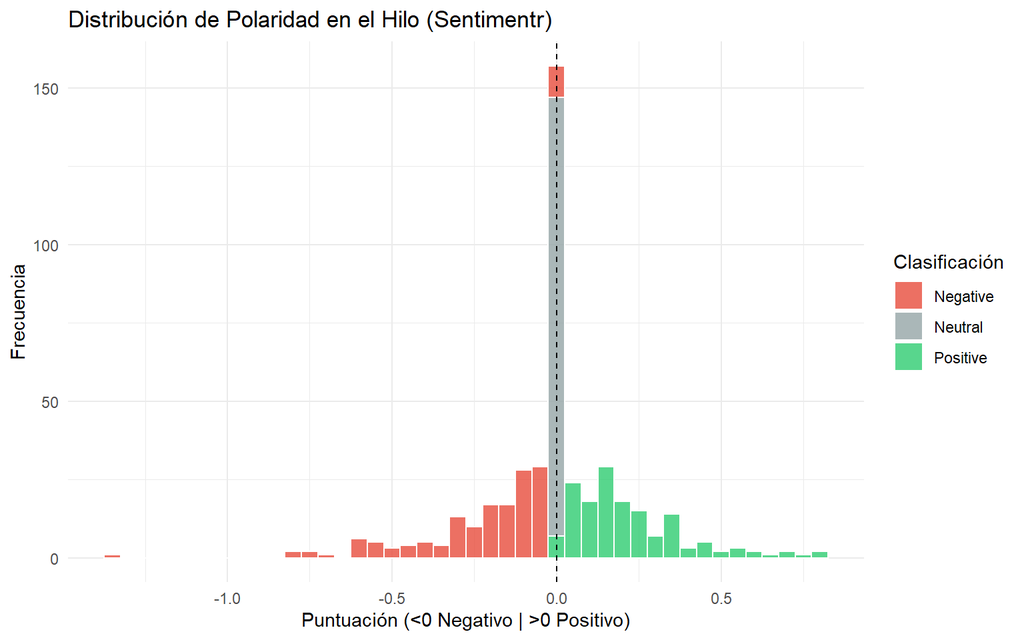

```r
# --- POLARIDAD CONTEXTUAL (Sentimentr) ---

ggplot(resultado_por_comentario, aes(x = sent_mean, fill = label)) +
  geom_histogram(binwidth = 0.05, color = "white", alpha = 0.8) +
  geom_vline(xintercept = 0, linetype = "dashed", color = "black") +
  scale_fill_manual(values = c("Negative" = "#E74C3C", "Neutral" = "#95A5A6", "Positive" = "#2ECC71")) +
  labs(
    title = "Distribución de Polaridad en el Hilo (Sentimentr)",
    x = "Puntuación (<0 Negativo | >0 Positivo)",
    y = "Frecuencia",
    fill = "Clasificación"
  ) +
  theme_minimal()
```

**Código**

```r
resultado_por_comentario %>%
  mutate(neutrality_score = abs(sent_mean)) %>%
  arrange(neutrality_score) %>%
  slice_head(n = 10) %>%

  select(text, sent_mean, neutrality_score) %>%
  knitr::kable(caption = "Tabla: Top 10 comentarios más Neutrales (Score más cercano a cero)")
```

Tabla: Top 10 comentarios más Neutrales (Score más cercano a cero)

| text | sent_mean | neutrality_score |
| --- | --- | --- |
| Another -25% day ffs? | 0 | 0 |
| 100K gone soon | 0 | 0 |
| we are so back! | 0 | 0 |
| It’s one point away, 20% | 0 | 0 |
| ETH is red on the year lmao | 0 | 0 |
| Are we cooked ? Or giga cooked | 0 | 0 |
| Giga mega hyper titanic cooked | 0 | 0 |
| What colour? | 0 | 0 |
| I’ll be getting one of each color, of course. | 0 | 0 |
| So whats not priced in then? | 0 | 0 |

En cuanto a la capacidad del modelo para detectar comentarios neutros, aqui tenemos la respuesta.

Esto nos muestra el límite más humano del modelo sentimentr confunde esta resignación exagerada con la neutralidad absoluta. Si bien corrigió las negaciones con éxito, su lógica contextual se rompe ante el sarcasmo extremo. El algoritmo puede fallar y meter en el mismo saco a un usuario tranquilo y uno con un pánico extremo.

A modo de conclusión este modelo, nos proporciona un resultado de los sentimientos hacía el mercado bastante neutral con muchos comentarios en contra y otros muchos positivos o neutros. No obstante este modelo tiene la limitación del humor o ironía extrema el cuál no es capaz de detectar.

### 1.3.2 LOUGHRAN

El siguiente paso es probar el modelo Loughran-McDonald. Esta herramienta es muy diferente a sentimentr; no se fija en la frase completa ni en el contexto, sino que funciona como un diccionario especializado en finanzas, lo cuál nos puede proporcionar una ventaja en este ámbito del mercado cripto.

La gran ventaja de este método es su precisión. Loughran fue creado para leer documentos de Wall Street, por lo que sabe distinguir muy bien entre las palabras que realmente hablan de miedo o riesgo y las palabras normales.Esto significa que tiene una mayor precisión en clasificar términos técnicos como coste o pasivo, no los clasifica como negativos directamente, al usar este modelo podemos descubrir con más exactitud cuales son las preocupaciones técnicas y reales de los inversores, que sentimentr no pudo captar.

**Código**

```r
# --- 1. PREPARACIÓN EN FORMATO TIDY (Un token por fila) ---

tokens_financieros <- df %>%
  unnest_tokens(word, comment) %>%
  anti_join(stop_words)

# --- 2. CARGA DEL LÉXICO FINANCIERO (Loughran) ---
loughran_lex <- get_sentiments("loughran")

# --- 3. CRUCE DE DATOS (INNER JOIN) ---
analisis_loughran <- tokens_financieros %>%
  inner_join(loughran_lex, by = "word")
```

Una vez que comprobamos las capacidad de sentimentr, ejecutamos el segundo método con el que vamos a ir directo al vocabulario del dinero.

Para que Loughran, que es un diccionario de palabras sueltas a diferencia de sentimentr, pudiera trabajar, seguimos el siguiente proceso.

Romper las frases con Unnest_tokens, convertimos el texto limpio en un objeto donde solo queda una palabra por fila tokens_financieros. Eliminamos las stop words porque en este análisis solo nos importa el contenido con carga financiera.

Con el análisis de dominio completado, ya tenemos la jerarquía de los miedos Loughran está lista para contrastar la polaridad conversacional obtenida con sentimentr.

Además, Loughran nos da una gran ventaja analítica: su clasificación nos permite ir más allá del simple veredicto de positivo o negativo, revelando dimensiones específicas como la incertidumbre y la litigiosidad que son cruciales para entender el pulso de este mercado volátil.

**Código**

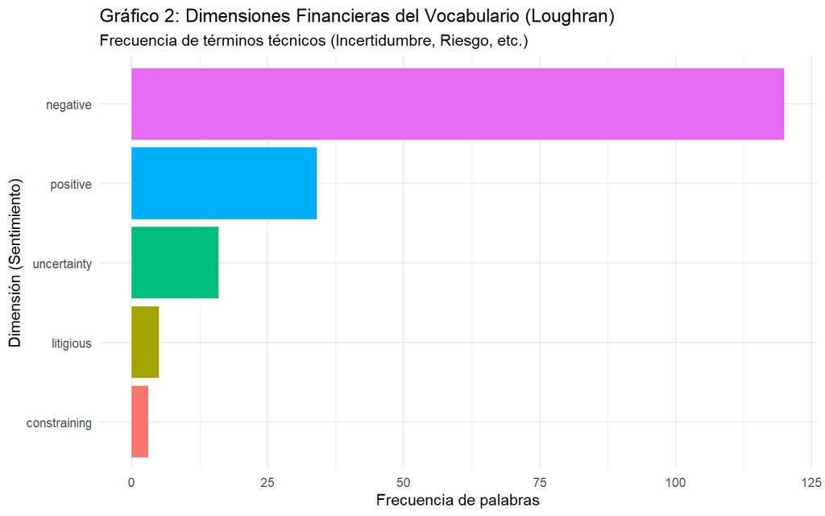

```r
conteo_dimensiones <- tokens_financieros %>%
  inner_join(loughran_lex, by = "word") %>%
  count(sentiment, sort = TRUE)

conteo_dimensiones_plot <- conteo_dimensiones %>%
  # Ordenamos las dimensiones por su frecuencia (n)
  mutate(sentiment = forcats::fct_reorder(sentiment, n)) %>%

  ggplot(aes(x = sentiment, y = n, fill = sentiment)) +
  geom_col(show.legend = FALSE) +
  coord_flip() + # Gráfico horizontal para leer los nombres largos (Uncertainty, Litigious)
  labs(
    title = "Gráfico 2: Dimensiones Financieras del Vocabulario (Loughran)",
    subtitle = "Frecuencia de términos técnicos (Incertidumbre, Riesgo, etc.)",
    x = "Dimensión (Sentimiento)",
    y = "Frecuencia de palabras"
  ) +
  theme_minimal()

conteo_dimensiones_plot
```

El análisis de Loughran presenta un resultado categórico el sentimiento negativo es dominante y supera al optimismo en una proporción significativa, lo que contrasta fuertemente con la distribución simétrica y equilibrada que obtuvimos previamente con Sentimentr. Esta divergencia en la polaridad no es un error, sino una diferencia metodológica crucial que nos obliga a reinterpretar la naturaleza de los sentimientos en el foro.

Esta predominancia del sentimiento negativo ocurre porque el léxico de Loughran está diseñado para ser selectivo. Fue creado para analizar informes financieros y de riesgo, ignorando deliberadamente cualquier palabra con carga emocional ambigua en el contexto económico. Es decir, mientras Sentimentr capta la euforia social e incluso el sarcasmo, Loughran filtra todo ese ruido y se centra únicamente en términos con implicaciones directas en el riesgo, la pérdida o la cautela.

**Código**

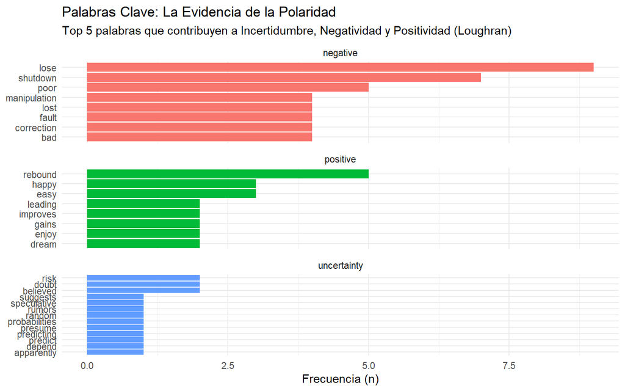

```r
# --- 5. PALABRAS CLAVE POR DIMENSIÓN ---
top_palabras_loughran <- analisis_loughran %>%
  count(word, sentiment, sort = TRUE) %>%
  group_by(sentiment) %>%
  slice_max(n, n = 5) %>% # Top 5 palabras por cada emoción
  ungroup() %>%
  mutate(word = reorder(word, n))


top_plot_data <- top_palabras_loughran %>%
  filter(sentiment %in% c("uncertainty", "negative", "positive"))


top_plot <- ggplot(top_plot_data, aes(x = n, y = forcats::fct_reorder(word, n), fill = sentiment)) +
  geom_col(show.legend = FALSE) +
  facet_wrap(~ sentiment, scales = "free_y", ncol = 1) + # Separamos por dimensión
  labs(
    title = "Palabras Clave: La Evidencia de la Polaridad",
    subtitle = "Top 5 palabras que contribuyen a Incertidumbre, Negatividad y Positividad (Loughran)",
    x = "Frecuencia (n)",
    y = NULL
  ) +
  theme_minimal()

top_plot
```

En el gráfico podemos observar las palabras más frecuentes que el algoritmo ha captado para cada dimensión, en este caso negativa positiva y de incertidumbre que son las más comparables a las dimensiones de sentimentr.

Observamos que como era de esperar la barra más larga, es decir la palabra más usada está en la dimensión de negatividad y es la palabra lose seguida de shootdown y poor,la siguiente dimensión que más ha aparecido es la positiva, donde la palabra más frecuente es rebound seguido de happy y finalmente la incerteza donde las palabras más frecuentes son risk y doubt.

Con este resultado podemos observar una confrontación muy fuerte entre los resultados equilibrados de sentimentr y los resultados de loughran.

## 1.4 CONCLUSIONES Y COMPARACIÓN

La confrontación entre las dos metodologías de análisis de sentimiento el léxico contextual Sentimentr y el léxico de dominio Loughran nos ha ofrecido una imagen diferente de la comunidad de r/CryptoCurrency.

Mientras que con sentimentr intentamos capturar más la ironía o humor que existen en estos foros, revelando una comunidad altamente polarizada con la negatividad y la positividad casi simétricas, rondando el $35\%$ cada una, este resultado demostró ser más un reflejo de la euforia volátil y el sarcasmo inherente al lenguaje informal. Los resultados de este método, aunque útiles para el tono general, se vieron sesgados por su dificultad para distinguir entre la verdadera y la burla o la ironía.

El análisis con el léxico de Loughran, diseñado específicamente para el lenguaje financiero y que ignora palabras de negatividad general sin implicaciones económicas directas, resultó ser el indicador de riesgo más veraz.

En síntesis, Sentimentr midió la emoción del momento, mientras que Loughran cuantificó la aversión al riesgo financiero. Ambos métodos, al ser utilizados en conjunto, revelan que detrás de una fachada de comentarios sarcásticos y optimismo volátil, existe un sólido fundamento de cautela y miedo a la incertidumbre.

Aunque es difícil dictaminar cuál es el que mejor análisis nos ofrece, la verdad es que su veracidad depende de la pregunta que formulemos. Sentimentr nos da una imagen más honesta del humor social y su volatilidad, pero es Loughran el que nos confirma la preocupación financiera real. Al usarlos de forma complementaria, superamos sus limitaciones y logramos una visión integral.

## 1.5 CONCLUSIÓN FINAL

El estudio sobre el análisis de sentimiento en el foro r/CryptoCurrency nos ha permitido entrar en la compleja psicología del inversor de cripto. Se confirma que el sentimiento en el mercado cripto es un mosaico de alta volatilidad emocional y profunda cautela financiera.

### 1.5.1 Limitaciones Encontradas

La mayor barrera para la precisión sigue siendo la naturaleza del lenguaje en foros informales. La ironía y el sarcasmo son la dificultad de los modelos basados en léxicos. El sistema interpreta la euforia sarcástica como alta positividad, distorsionando la realidad del humor de la comunidad.

Además, el corpus analizado es una fotografía de un solo día ya que es, el hilo de discusión diaria, limitando la capacidad de extraer conclusiones robustas sobre tendencias a largo plazo.

### 1.5.2 Recomendaciones de Futuro

De cara a investigaciones futuras, las mejoras deberían centrarse en superar estas limitaciones lingüísticas y de escala:

Anotación Manual y Modelos Avanzados: Para abordar el problema del sarcasmo, sería fundamental crear un subconjunto de datos con anotaciones manuales.

Escala Temporal y Causalidad: Seria también conveniente expandir el corpus a un período más largo y realizar un análisis de series de tiempo. Esto permitiría correlacionar las variaciones en el sentimiento con los movimientos de precio de las criptomonedas, lo que podría ayudar a determinar si el sentimiento es un factor predictor o una simple reacción a los eventos del mercado.